# Statistica inferenziale

## Stime della media

### Una popolazione gaussiana

Consideriamo il dataset *Resa estrattiva*

```r
data(Resa_estrattiva,package = "Master")
Resa_estrattiva
```

|  | Resa |
| --- | --- |
| 1 | 13.84 |
| 2 | 18.77 |
| 3 | 17.85 |
| 4 | 23.05 |
| 5 | 19.27 |
| 6 | 20.87 |
| 7 | 17.35 |
| 8 | 22.37 |
| 9 | 21.45 |
| 10 | 19.40 |

Il dataset consiste in 10 misure sperimentali della *Resa estrattiva* di un metodo di isolamento di polifenoli da infusi acquosi di Dittamo cretese (*Origanum dictamus*, meglio noto come *Cretan tea*), una pianta aromatica e medicinale tradizionalmente considerata un rimedio generale per molti disturbi (dalla stanchezza ai disturbi digestivi, alla capacità di agire come disinfettante e cicatrizzante), già descritto nel capitolo *Statistica descrittiva*.  
Siamo ora interessati ad ottenere informazioni su tutta la popolazione partendo dal campione (aleatorio) delle 10 misure sperimentali. Ad esempio possiamo chiederci qual’ è la media “vera” della nostra resa estrattiva o meglio come possiamo stimare tale valore a partire dai 10 risultati sperimentali.

Supponiamo che le $m=10$ misure della *Resa estrattiva* possano essere modellizate come
$$\begin{equation}\label{eq:mod_media}
y_i=\mu+\epsilon_i, \qquad i=1,\dots,m,
\end{equation}$$

dove $\epsilon_i \sim N(0,\sigma^2)$ a due a due non correlate. Supponiamo cioè che $y_1,\dots,y_{10}$ siano normali di media $\mu$ e varianza $\sigma^2$ e siano indipendenti.

#### Varianza $\sigma^2$ nota

Una stima puntuale di $\mu$ è data da
$$\begin{equation}
\bar{y}=\frac{\sum_{i=1}^{m} y_i}{m}
\end{equation}$$

Calcoliamo $\bar{y}$

```r
sum(Resa_estrattiva$Resa)/length(Resa_estrattiva$Resa)
```

```
## [1] 19.422
```

Lo stesso valore è ottenuto con il comando

```r
mean(Resa_estrattiva$Resa)
```

```
## [1] 19.422
```

Si può dimostrare che
$$\begin{equation}\label{eq:distr_media}
\frac{\bar{y}-\mu}{\sigma \sqrt{1/m}} \sim N(0,1).
\end{equation}$$

La densità della distribuzione $N(0,1)$ è rappresentata in Figura .  
La quantità $\sigma \sqrt{1/m}$, deviazione standard della stima puntuale della media $\bar{y}$, è chiamata *errore standard della media*.

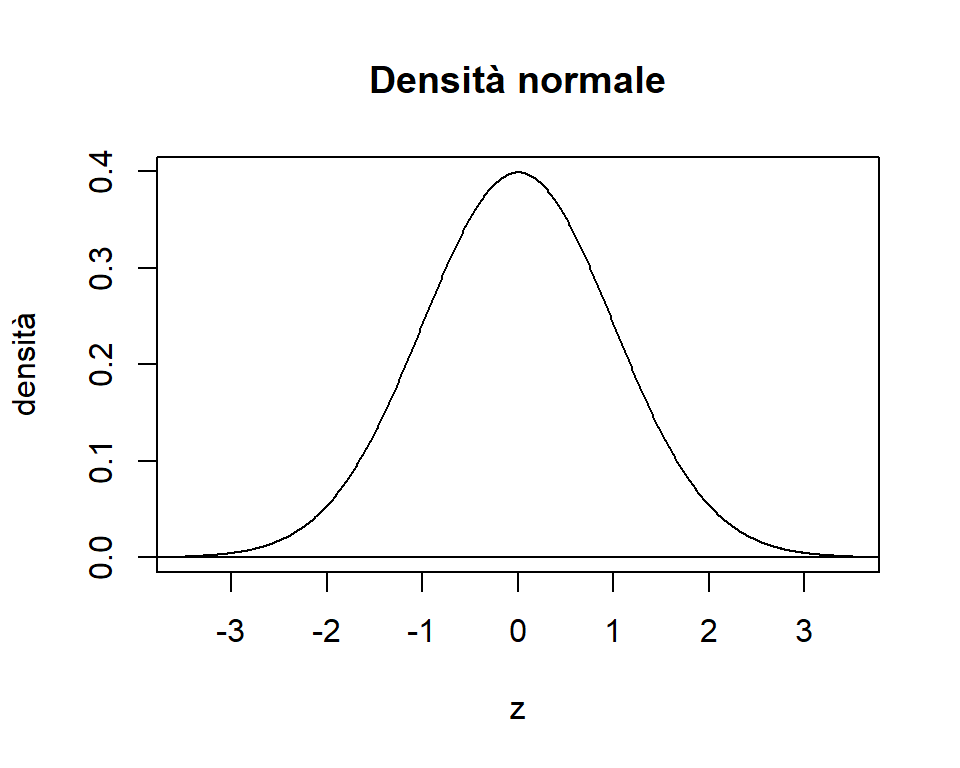

Densità della distribuzione $N(0,1)$

Ricordo brevemente il significato di densità di una distribuzione di probabilità. L’area sottesa tra i valori $x_1$ e $x_2$ è la probabilità che una variabile così distribuita sia compresa tra $x_1$ e $x_2$ (l’area totale è 1).  
Ad esempio in Figura l’area in blu è la probabilità che una variabile z distribuita come N(0,1) sia compresa tra 0 e 1: $\mathbb{P}[0<z<1], z\sim N(0,1)$.

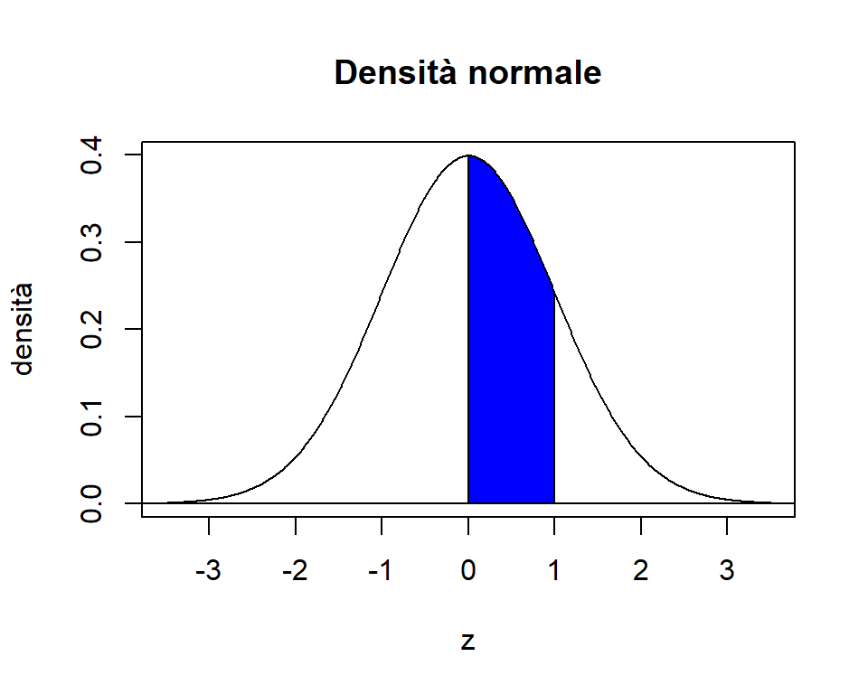

$\mathbb{P}[0<z<1], z\sim N(0,1)$

Per il *teorema centrale del limite* le ipotesi del modello () possono essere alleggerite se il numero di osservazioni $m$ è grande (ad esempio $m>30$). E’ sufficiente supporre che le variabili $y_i$ siano indipendenti e identicamente distribuite di media $\mu$ e varianza $\sigma^2$.

La stima puntuale () del parametro $\mu$ resta una risposta piuttosto grossolana al problema di determinare una ragionevole approssimazione del valore vero incognito. In particolare è evidente che il valore stimato non sarà mai uguale al valore vero. Grazie alla () possiamo introdurre una stima per intervalli.  
Fissiamo un valore $\alpha$ compreso tra 0 e 1 (in generale $\alpha=0.05$). Determiniamo il quantile di ordine $1-\alpha/2$, ossia quel valore $z_{\alpha/2}$ tale che $\mathbb{P}[z<z_{\alpha/2}]=1-\alpha/2$ (equivalentemente $\mathbb{P}[z>z_{\alpha/2}]=\alpha/2$). Per $\alpha=0.05$:

```r
quant=qnorm(p = 0.975,mean = 0,sd = 1)
quant
```

```
## [1] 1.959964
```

Per quanto detto precedentemente la probabilità che $\frac{\bar{y}-\mu}{\sigma \sqrt{1/m}}$ sia compreso tra -1.959964 e 1.959964 è del 95%. Si veda Figura

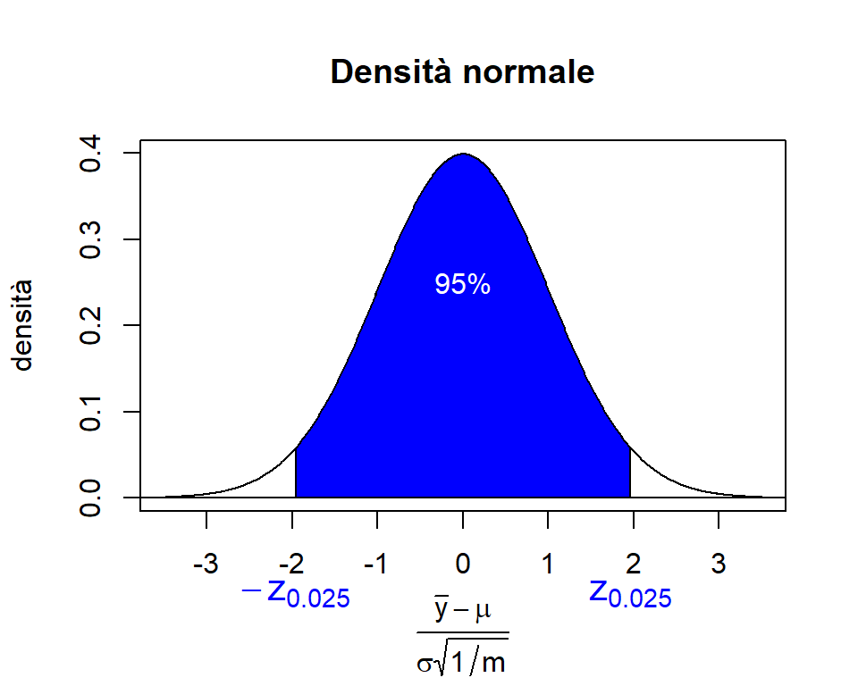

$\mathbb{P}[-z_{0.025}<\frac{\bar{y}-\mu}{\sigma \sqrt{1/m}}<z_{0.025}]=0.95$

Consideriamo l’intervallo
$$\begin{equation}\label{eq:IntConf}
[\bar{y}-z_{\alpha/2}\frac{\sigma}{\sqrt{m}},\bar{y}+z_{\alpha/2}\frac{\sigma}{\sqrt{m}}]
\end{equation}$$

chiamato *intervallo di confidenza di livello $\alpha$*. E’ un intervallo (aleatorio) che ha “probabilità $1-\alpha$” di contenere il valore vero della media $\mu$, nel senso che ripetendo la costruzione di () un numero elevato di volte (eseguendo un numero elevato di volte 10 misure sperimentali da cui ricavarer $\bar{y}$…. ) circa $1-\alpha$ intervalli così costruiti contengono $\mu$.

Suppponiamo che $\sigma=2.17$, calcoliamo gli estremi dell’intervallo di confidenza () di livello $\alpha=0.05$:

```r
mean(Resa_estrattiva$Resa)-quant*(2.17/sqrt(10))
```

```
## [1] 18.07704
```

```r
mean(Resa_estrattiva$Resa)+quant*(2.17/sqrt(10))
```

```
## [1] 20.76696
```

Grazie alla () possiamo testare l’ipotesi $\mu=\mu_0$ (ipotesi nulla $H_0$, che consideriamo vera “fino a prova contraria”) contro l’ipotesi $\mu \neq \mu_0 \quad (\rm{opp.} \ \mu>\mu_0 \ \rm{opp.}\ \mu<\mu_0)$ (ipotesi alternativa $H_1$)
$$\begin{equation*}
H_0: \mu=\mu_0 \quad \rm{vs} \quad H_1: \mu \neq \mu_0 \quad (\rm{opp.} \ \mu>\mu_0 \ \rm{opp.}\ \mu<\mu_0).
\end{equation*}$$

nel seguente modo. Fissiamo un valore $\alpha$ tra $0$ e $1$ (in generale viene scelto $\alpha = 0.05$) e definiamo una regione, che chiameremo Regione Critica RC, come la regione in blu in Figura .  
Per la () la stima $z_0=\frac{\bar{y}-\mu_0}{\sigma \sqrt{1/m}}$ ha probabilità $1-\alpha$ di non cadere nella RC (zona bianca), vedi Figura a) e ha probabilità $\alpha$ di cadere nella RC (zona blu), vedi Figura b).

Accettiamo ipotesi nulla $H_0$ se la stima $z_0$ non cade nella RC, Figura a), infatti, in tal caso non abbiamo evidenza statistica per rifiutare ipotesi nulla, mentre rifiutiamo ipotesi nulla nel caso contrario, Figura b). In tal caso diremo che $\mu$ è significativamente diversa da $\mu_0$ al livello $\alpha$.  
Si osservi che $\alpha$ è la probabilità di rifiutare l’ipotesi nulla $H_0$ quando questa è vera (errore di tipo I). Probabilità che si vuole tenere piccola. Come già detto in generale si fissa $\alpha=0.05$.

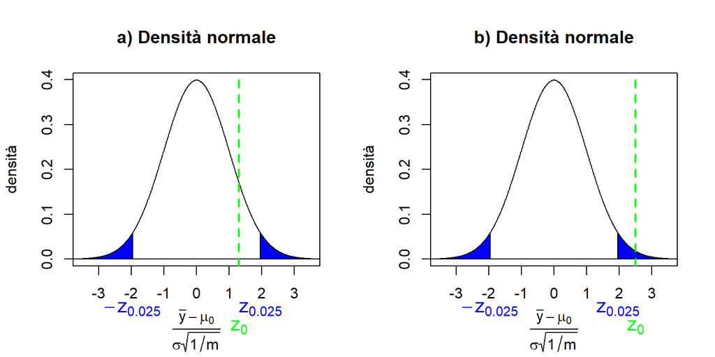

Regione critica

Calcolata la stima $z_0$ chiamiamo *p-value* la probabilità che la variabile (aleatoria) $\frac{\bar{y}-\mu_0}{\sigma \sqrt{1/m}}$ sia maggiore di $z_0$ e minore di $-z_0$
$$\begin{equation}
\mathbb{P}[|z|>z_0]
\end{equation}$$

Figura zona verde.  
Accettiamo quindi l’ipotesi nulla $H_0$ se *p-value* è maggiore di $\alpha$, e rifiutiamo $H_0$ nel caso contrario.  
Il *p-value* è il più piccolo valore di $\alpha$ per cui abbiamo evidenza statistica per rifiutare $H_0$.

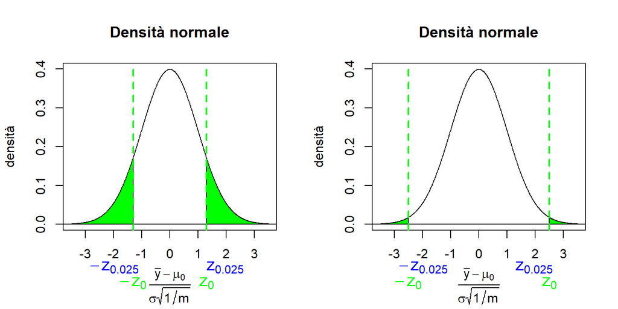

p-value

Torniamo al nostro esempio numerico. Da un altro gruppo di esperimenti sulla stessa pianta si ottiene il valore medio di 17.82.  
Vogliamo testare l’ipotesi $\mu=17.82$ (ipotesi nulla $H_0$) contro l’ipotesi $\mu \neq 17.82$ (ipotesi alternativa $H_1$).  
Calcoliamo la statistica $z_0$

```r
z.0=(mean(Resa_estrattiva$Resa)-17.82)/(2.17/sqrt(10))
z.0 # statistica
```

```
## [1] 2.334548
```

Essendo il valore calcolato maggiore di $z_{\alpha/2}$, Figura a) abbiamo evidenza statistica (con livello di significatività $\alpha=0.05$) di rifiutare l’ipotesi nulla $H_0$.

Calcoliamo la probabilità che $\frac{\bar{y}-17.82}{\sigma \sqrt{1/m}}>z_0$ (coda verde destra Figura b))

```r
pnorm(q = z.0,mean = 0,sd = 1,lower.tail = FALSE)
```

```
## [1] 0.009783527
```

La probalità che $\frac{\bar{y}-17.82}{\sigma \sqrt{1/m}}<-z_0$ (coda verde sinistra Figura b))

```r
pnorm(q = -z.0,mean = 0,sd = 1,lower.tail = TRUE)
```

```
## [1] 0.009783527
```

è, per simmetria, uguale alla probabilità che $\frac{\bar{y}-17.82}{\sigma \sqrt{1/m}}>z_0$.  
Il *p-value* è quindi

```r
pnorm(q = z.0,mean = 0,sd = 1,lower.tail = FALSE) *2  # p-value.
```

```
## [1] 0.01956705
```

Essendo minore di 0.05, come abbiamo già visto, abbiamo evidenza statistica per rifiutare $H_0$.  
Osserviamo che se avessimo fissato $\alpha=0.02$, dato il valore del *p-value*, avremmo comunque avuto evidenza per poter rifiutare $H_0$. Il *p-value*, se vogliamo, è una sorta di indicatore di quanto “è statisticamente evidente” il rifiuto dell’ipotesi nulla $H_0$.

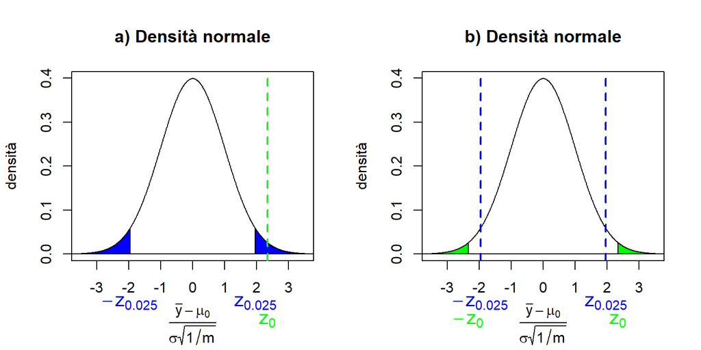

Test ipotesi $H_0: \mu_0=17.82$ ($\sigma=2.17$)

Dobbiamo ora verificare che le ipotesi del modello () siano verificate: dobbiamo verificare che le 10 misure sperimentali provengano da una popolazione normale $N(\mu,\sigma^2)$. Esiste un semplice metodo grafico per testare questa ipotesi, il Q-Q Plot (Quantile -Quantile Plot). Il grafico riporta in ascissa i quantili della $N(0,1)$ e in ordinate i quantili della distribuzione campionaria dei dati, Figura .

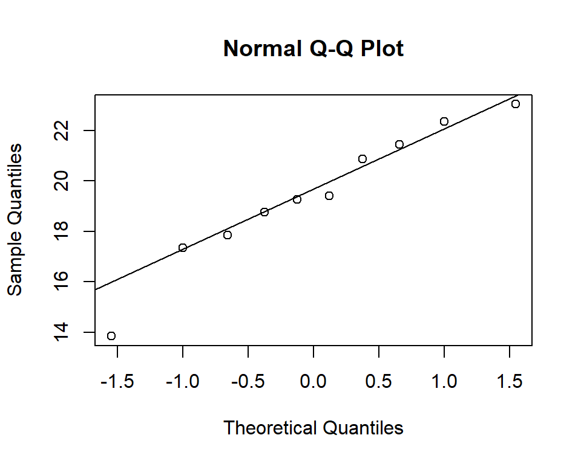

Quantile-Quantile Plot

Tanto più i quantili sono allineati tanto più i dati confermano l’ipotesi di normalità

Esiste un test, **test di Shapiro-Wilk**, considerato uno dei più potenti per la verifica della normalità, soprattutto per piccoli campioni. Il test confronta una varianza ottenuta usando pesi particolari con la varianza campionaria. Indicata con $W$ il rapporto tra le due stime della varianza ($0<W<1$), nell’ipotesi di normalità (ipotesi nulla $H_0$) viene rifiutata l’ipotesi nulla per valori di $W$ troppo piccoli

```r
shapiro.test(Resa_estrattiva$Resa)
```

```
##
##  Shapiro-Wilk normality test
##
## data:  Resa_estrattiva$Resa
## W = 0.95616, p-value = 0.7414
```

Il valore del *p-value* è molto grande e quindi accettiamo l’ipotesi che il nostro campione provenga da una popolazione normale, o meglio non abbiamo sufficiente evidenza statistica per poter rifiutare tale ipotesi.

#### Varianza $\sigma^2$ non nota

In questo caso dobbiamo stimare anche $\sigma^2$. Una stima puntuale della varianza $\sigma^2$ è data da
$$\begin{equation*}
s^2 = \frac{1}{m-1}\sum_{j=1}^m (y_j-\bar y)^2.
\end{equation*}$$

Calcoliamo $s^2$

```r
sum((Resa_estrattiva$Resa-mean(Resa_estrattiva$Resa))^2)/(length(Resa_estrattiva$Resa)-1)
```

```
## [1] 7.381596
```

Lo stesso valore è ottenuto con il comando

```r
var(Resa_estrattiva$Resa)
```

```
## [1] 7.381596
```

Si puo dimostrare
$$\begin{equation}\label{eq:DistrSigmaq}
\frac{(m-1)s^2}{\sigma^2} \sim \chi^2(m-1).
\end{equation}$$

La densità di distribuzione $\chi^2(n)$ è rappresentata in Figura .

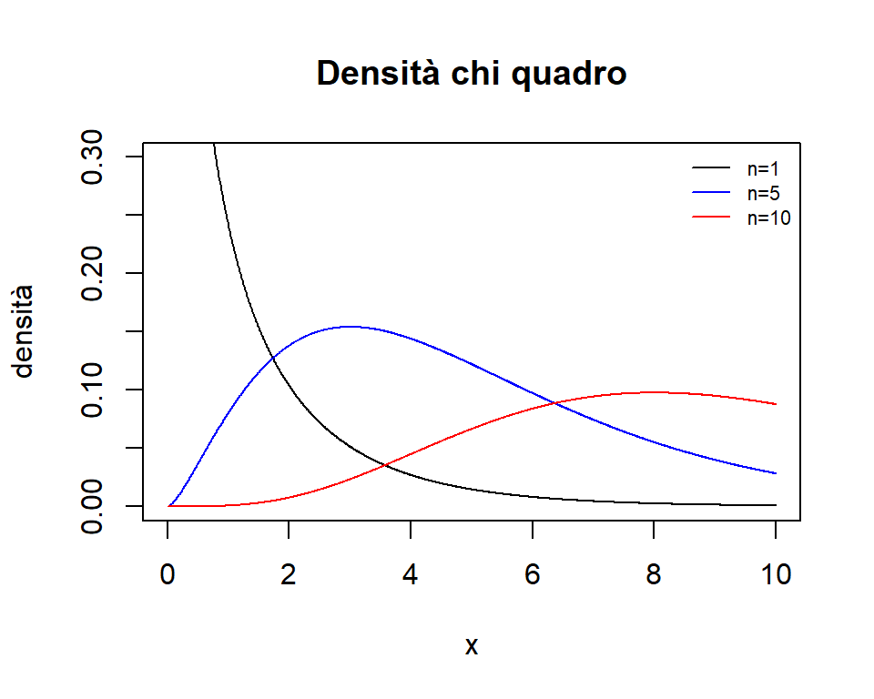

Densità della distribuzione $\chi^2$

Ricordo che
$$\begin{equation}
x_1^2+\dots+x_n \sim \chi^2(n), \quad x_i \sim N(0,1).
\end{equation}$$
Si può quindi dimostrare che
$$\begin{equation}\label{eq:DistrMediattest}
\frac{\bar y - \mu}{s \sqrt{1/m}} \sim t(m-1).
\end{equation}$$

La distribuzione $t(n)$ è rappresentata in Figura .

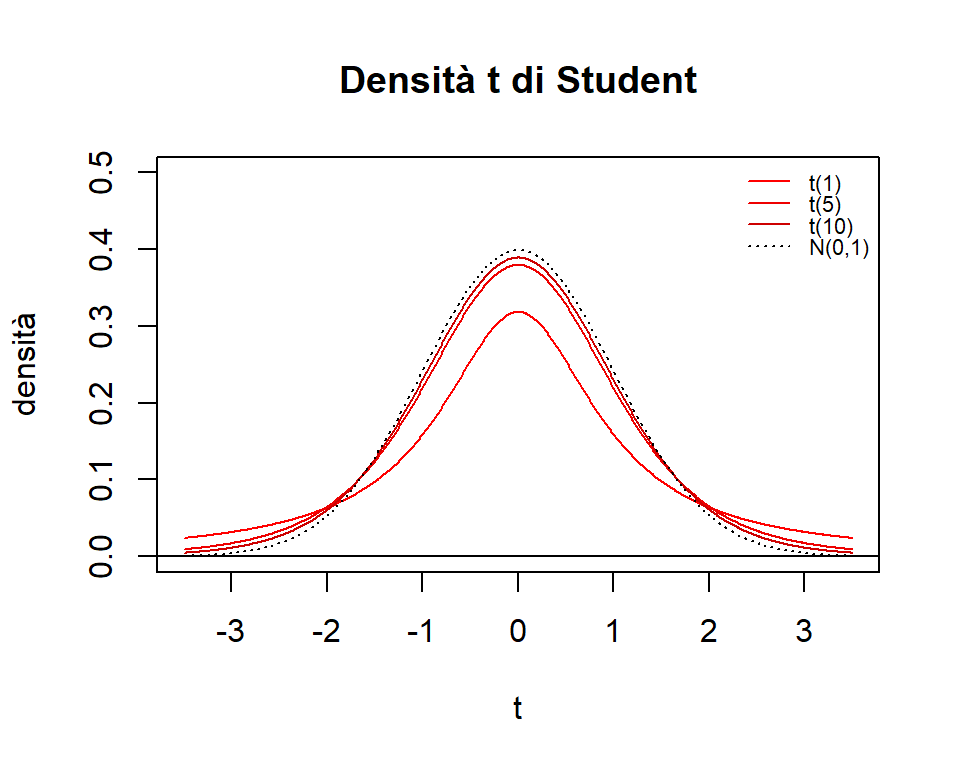

Densità della distribuzione $t$ di Student

Ricordo che
$$\begin{equation}
\frac{z}{\sqrt{x^2/n}} \sim t(n), \quad z\sim N(0,1), \ x^2 \sim \chi^2(n).
\end{equation}$$

La quantità $s$ nella () è la deviazione standard del campione, è una stima - consistente non distorta - della deviazione standard della popolazione.

```r
sd(Resa_estrattiva$Resa) # deviazione standard
```

```
## [1] 2.716909
```

La quantità $s \sqrt{1/m}$ nella () è *l’errore standard della media*, ossia la stima della deviazione standard della media. È dunque una stima della variabilità della stima della media, cioè una misura della sua imprecisione.  
Nel nostro esempio risulta:

```r
sd(Resa_estrattiva$Resa)/sqrt(10) # errore standard
```

```
## [1] 0.8591621
```

dove $t_{\alpha /2,m-1}$ indica il quantile di ordine $1-\alpha/2$ della distribuzione $t$ di $m-1$ gradi di libertà, i.e. $\mathbb{P}[t \geq t_{\alpha /2,m-1}]=\alpha/2$, $t\sim t(m-1)$.

Tornando al nostro esempio: supponiamo che da un altro gruppo di esperimenti sulla stessa pianta si ottiene il valore medio di 18.02. Vogliamo testare l’ipotesi nulla $\mu_0=18.02$. Ci chiediamo “18.02 e 19.42 sono statisticamente distinguibili”?

Con il comando

```r
t.test(Resa_estrattiva,mu = 18.02)
```

```
##
##  One Sample t-test
##
## data:  Resa_estrattiva
## t = 1.6318, df = 9, p-value = 0.1372
## alternative hypothesis: true mean is not equal to 18.02
## 95 percent confidence interval:
##  17.47844 21.36556
## sample estimates:
## mean of x
##    19.422
```

otteniamo la statistica $t=\frac{\bar y - \mu_0}{s \sqrt{1/m}}$ ($\mu_0=18.02$), i gradi di libertà *df* , *p-value* del *t-test*, l’estremo inferiore e l’estremo superiore dell’intervallo di confidenza di livello 95% e la stima della media.

In questo caso si vede che dobbiamo accettare ipotesi nulla, $p$-$value=0.1372$, i.e. la probabilità che data per vera l’ipotesi nulla si abbia una stima della media maggiore o uguale a quella ottenuta è del $13.72 \%$.

Può essere un utile esercizio seguire passo passo quanto fatto nel paragrafo precedende e calcolare direttamente quanto appena ottenuto.

La verifica che siano sodisfatte le ipotesi di normalità è stata fatta paragrafo precedente

### Due popolazioni gaussiane: campioni accoppiati

Consideriamo il dataset *Diuretico*

```r
data(Diuretico, package = "Master")
Diuretico
```

| Paziente | Diuretico.A | Diuretico.B |
| --- | --- | --- |
| 1 | 3.5 | 4.0 |
| 2 | 4.0 | 4.2 |
| 3 | 4.6 | 4.9 |
| 4 | 7.1 | 5.6 |
| 5 | 3.1 | 5.1 |
| 6 | 5.5 | 5.0 |
| 7 | 6.8 | 5.7 |
| 8 | 5.1 | 7.1 |
| 9 | 5.6 | 6.2 |
| 10 | 3.8 | 5.2 |

[output cut: 2 more lines]

Il dataset consiste in 12 pazienti a cui vengono somministrati 2 diuretici A e B ……..  
In questo caso i campioni sono accoppiati in quanto le misure delle 2 variabili *Diuretico.A* e *Diuretico.B* sono riferite allo stesso paziente.

Si costruisce il campione delle differenze

```r
z=Diuretico$Diuretico.A-Diuretico$Diuretico.B
```

al quale si può applicare quanto detto nei paragrafi precedenti.

Ad esempio se vogliamo testare l’ipotesi $\mu_A=\mu_B$ ($\mu_z=0$)

```r
t.test(z)
```

```
##
##  One Sample t-test
##
## data:  z
## t = -1.215, df = 11, p-value = 0.2498
## alternative hypothesis: true mean is not equal to 0
## 95 percent confidence interval:
##  -1.1480354  0.3313687
## sample estimates:
##  mean of x
## -0.4083333
```

Lo stesso risultato si può ottenere con il comando

```r
t.test(Diuretico$Diuretico.A, Diuretico$Diuretico.B, paired=TRUE)
```

```
##
##  Paired t-test
##
## data:  Diuretico$Diuretico.A and Diuretico$Diuretico.B
## t = -1.215, df = 11, p-value = 0.2498
## alternative hypothesis: true difference in means is not equal to 0
## 95 percent confidence interval:
##  -1.1480354  0.3313687
## sample estimates:
## mean of the differences
##              -0.4083333
```

### Due popolazioni gaussiane: campioni indipendenti

Consideriamo il dataset *Resa estrattiva gruppi*

```r
data(Resa_estrattiva_gruppi,package = "Master")
Resa_estrattiva_gruppi
```

| Resa | Gruppo |
| --- | --- |
| 13.83871 | a |
| 18.76667 | b |
| 17.85000 | a |
| 23.05000 | b |
| 19.26667 | a |
| 20.87097 | b |
| 17.35484 | a |
| 22.37097 | b |
| 21.45000 | a |
| 19.40323 | b |

Il dastaset consiste nelle 10 misure sperimentali della *Resa estrattiva* considerate nei paragrafi precedenti a cui è aggiunta una variabile qualitativa (fattore a 2 livelli) *Gruppo* in cui è indicato il gruppo a cui appartiene la misura i-esima.

```r
str(Resa_estrattiva_gruppi)
```

```
## Classes 'tbl_df', 'tbl' and 'data.frame':    10 obs. of  2 variables:
##  $ Resa  : num  13.8 18.8 17.9 23 19.3 ...
##  $ Gruppo: Factor w/ 2 levels "a","b": 1 2 1 2 1 2 1 2 1 2
```

Possiamo rappresentare i dati in 2 colonne come segue

```
##     Resa.a   Resa.b
## 1 13.83871 18.76667
## 2 17.85000 23.05000
## 3 19.26667 20.87097
## 4 17.35484 22.37097
## 5 21.45000 19.40323
```

Possiamo decomporre le osservazioni
$$\begin{equation*}
y_{ij}=\bar{y}+(\bar{y_i}-\bar{y})+(y_{ij}-\bar{y_i}),
\end{equation*}$$

dove $\bar{y}$ è la media delle 10 misure della *Resa estrattiva* e $\bar{y_i}$ è la media delle osservazioni del *Gruppo* $i$ (colonna $i$-esima).

Supponiamo che i dati possano essere modellizzati ($\mu_a=\mu+\alpha_a$ e $\mu_b=\mu+\alpha_b$)
$$\begin{equation}\label{eq:ModDuePopGauss}
y_{ij}=\mu+\alpha_i+\epsilon_{ij}, \qquad i=a,b,\quad j=1,\dots,m_i,
\end{equation}$$

dove $\epsilon_{aj} \sim N(0,\sigma_a^2)$ e $\epsilon_{bj} \sim N(0,\sigma_b^2)$ a due a due non correlate.

#### Varianze $\sigma^2_a$ e $\sigma^2_b$ note

Una stima puntuale di $\mu_a$ e $\mu_b$ è data rispettivamente da
$$\begin{equation}
\bar y_a = \frac{1}{m_a}\sum_{i=1}^{m_a} y_{aj} \qquad
\bar y_b = \frac{1}{m_b}\sum_{i=1}^{m_b} y_{bj}
\end{equation}$$

Calcoliamole per il nostro esempio

```r
aggregate(Resa~Gruppo,data = Resa_estrattiva_gruppi,FUN = mean)
```

| Gruppo | Resa |
| --- | --- |
| a | 17.95204 |
| b | 20.89237 |

Si può provare che
$$\begin{equation}
\frac{(\bar y_a - \bar y_b)-(\mu_a-\mu_b)}{\sqrt{\sigma^2_a/m_a+\sigma^2_b/m_b}} \sim N(0,1)
\end{equation}$$

Si può applicare quanto detto nel Paragrafo

#### Varianze $\sigma^2_a$ e $\sigma^2_b$ non note

Si può applicare quanto detto nel Paragrafo

Abbiamo quindi bisogno di verificare l’ipotesi di uguaglianza delle varianze dei due campioni.
Ricordando la () si può dimostrare che
$$\begin{equation}
\frac{s^2_a/\sigma^2_a}{s^2_b/\sigma^2_b} \sim F(m_a-1,m_b-1).
\end{equation}$$
La densità della distribuzione $F(m,n)$ è rappresentata in Figura
Ricordo che
$$\begin{equation}\label{eq:DistrVarFTest}
\frac{x^2/m}{y^2/n} \sim F(m,n), \quad x^2 \sim \chi^2(m), y^2 \sim \chi^2(n).
\end{equation}$$

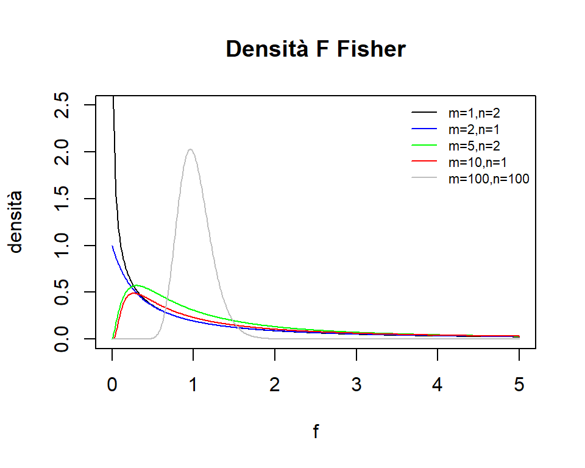

Densità della distribuzione $F(m,n)$

dove $f_{\alpha/2}$ indica il quantile di ordine $1-\alpha/2$ della distribuzione $F(m_a-1,m_b-1)$, i.e. $\mathbb{P}[f \geq f_{\alpha/2}]=\alpha/2$, $f\sim F(m_a-1,m_b-1)$.

Tornando al nostro esempio. Calcoliamo la statistica $f_0=s^2_a/s^2_b$

```r
s=aggregate(Resa~Gruppo,data = Resa_estrattiva_gruppi,FUN = sd)
s
```

| Gruppo | Resa |
| --- | --- |
| a | 2.795108 |
| b | 1.842433 |

```r
s.a=s$Resa[s$Gruppo=="a"]
s.b=s$Resa[s$Gruppo=="b"]
f.0=s.a^2/s.b^2 # statistica F
f.0
```

```
## [1] 2.301514
```

Essendo il valore calcolato maggiore di $f_{1-\alpha/2}$

```r
qf(p = 0.025,df1 = 4,df2 = 4,lower.tail = TRUE)
```

```
## [1] 0.1041175
```

e minore di $f_{\alpha/2}$

```r
qf(p = 0.025,df1 = 4,df2 = 4,lower.tail = FALSE)
```

```
## [1] 9.60453
```

non abbiamo evidenza statistica per rifiutare l’ipotesi nulla (vedi Figura a)) e possiamo quindi considerare le varianze uguali.

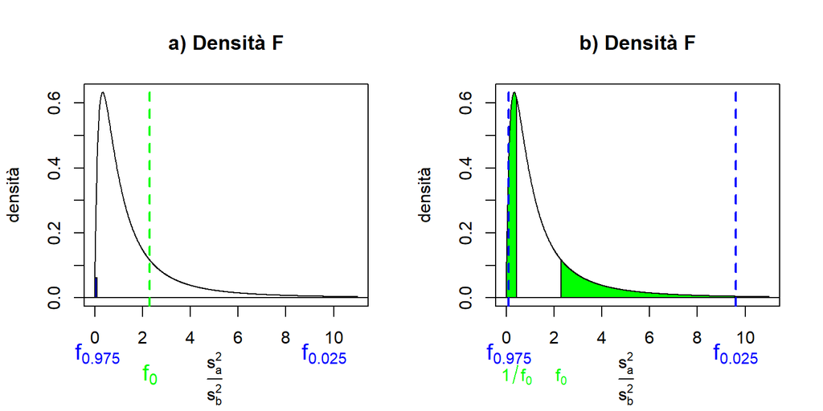

Test ipotesi $H_0: \sigma^2_a=\sigma^2_b$

Il *p-value* (vedi Figura b)) lo possiamo calcolare come segue

```r
pf(q = f.0,df1 = 4,df2 = 4,lower.tail = FALSE)+pf(q = 1/f.0,df1 = 4,df2 = 4,lower.tail = TRUE)
```

```
## [1] 0.4393061
```

Essendo maggiore di 0.05 non abbiamo evidenza statistica per rifiutare $H_0$.

Per esercizio calcoliamo anche gli estremi dell’intervallo di confidenza

```r
f.0*1/qf(p = 0.025,df1 = 4,df2 = 4,lower.tail = TRUE)
```

```
## [1] 22.10496
```

```r
f.0*1/qf(p = 0.025,df1 = 4,df2 = 4,lower.tail = FALSE)
```

```
## [1] 0.239628
```

Osserviamo che 1 è compreso nell’intervallo di confidenza, come ci aspettiamo dal valore del *p-value*. Il test per confrontare le varianze, F-test, si può ottenere con il comando

```r
var.test(Resa ~ Gruppo, data=Resa_estrattiva_gruppi)
```

```
##
##  F test to compare two variances
##
## data:  Resa by Gruppo
## F = 2.3015, num df = 4, denom df = 4, p-value = 0.4393
## alternative hypothesis: true ratio of variances is not equal to 1
## 95 percent confidence interval:
##   0.239628 22.104961
## sample estimates:
## ratio of variances
##           2.301514
```

otteniamo la statistica $f_0=s^2_a/s^2_b$, i gradi di libertà del numeratore e del denominatore, l’estremo inferiore e superiore dell’intervallo di confidenza di livello 95% e la stima del rapporto $\sigma^2_a/\sigma^2_b$.

Per eseguire il *t-test* per confrontare le medie, vedi (), nel caso di varianze uguali si usa il comando

```r
t.test(Resa~Gruppo,data=Resa_estrattiva_gruppi,var.equal=TRUE)
```

```
##
##  Two Sample t-test
##
## data:  Resa by Gruppo
## t = -1.964, df = 8, p-value = 0.08514
## alternative hypothesis: true difference in means is not equal to 0
## 95 percent confidence interval:
##  -6.3927411  0.5120959
## sample estimates:
## mean in group a mean in group b
##        17.95204        20.89237
```

Essendo il *p-value* maggiore di 0.05 o analogamente osservando che l’intervallo di confidenza contiene lo 0 non abbiamo evidenza per rifiutare l’ipotesi nulla e quindi posssiamo considerare le due medie uguali.

Dobbiamo verificare le ipotesi di normalità del modello (). Vedi Figura

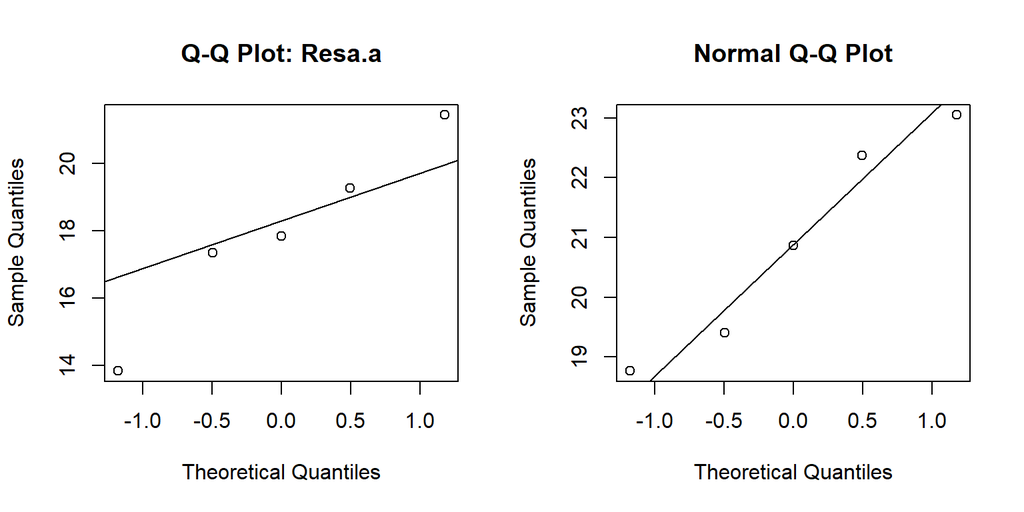

Quantile-Quantile Plot

Eseguiamo il test di *Shapiro-Wilk* per la popolazione *Resa.a*

```r
shapiro.test(Resa_estrattiva_gruppi[Resa_estrattiva_gruppi$Gruppo=="a",]$Resa)
```

```
##
##  Shapiro-Wilk normality test
##
## data:  Resa_estrattiva_gruppi[Resa_estrattiva_gruppi$Gruppo == "a",     ]$Resa
## W = 0.97511, p-value = 0.9069
```

e per la popolazione *Resa.b*

```r
shapiro.test(Resa_estrattiva_gruppi[Resa_estrattiva_gruppi$Gruppo=="b",]$Resa)
```

```
##
##  Shapiro-Wilk normality test
##
## data:  Resa_estrattiva_gruppi[Resa_estrattiva_gruppi$Gruppo == "b",     ]$Resa
## W = 0.93504, p-value = 0.6311
```

I due test non evidenzano non normalità delle due popolazioni.

Eseguiamo il *t-test* senza supporre le varianze uguali

```r
t.test(Resa~Gruppo,data=Resa_estrattiva_gruppi,var.equal=FALSE)
```

```
##
##  Welch Two Sample t-test
##
## data:  Resa by Gruppo
## t = -1.964, df = 6.924, p-value = 0.09074
## alternative hypothesis: true difference in means is not equal to 0
## 95 percent confidence interval:
##  -6.4883999  0.6077548
## sample estimates:
## mean in group a mean in group b
##        17.95204        20.89237
```

Si osservi che essendo i gradi di libertà stimati dalla *formula di Welch* $\nu = 6.924$ minori di 8 (gradi di libertà nel caso in cui le varianze siano uguali) il test è “meno potente nel distinguere le medie”. Questo lo si nota dal valore del *p-value* che risulta maggiore e dall’intervallo di confidenza che risulta più ampio.  
Resta uguale la statistica $t_0$.

## Analisi della varianza

### ANOVA a 1 via

Consideriamo il dataset *Collirio*

```r
data(Collirio,package = "Master")
Collirio
```

| Preparazione | Pesata |
| --- | --- |
| Nessuna | 0.0285 |
| Nessuna | 0.0304 |
| Nessuna | 0.0295 |
| Nessuna | 0.0318 |
| Nessuna | 0.0303 |
| Nessuna | 0.0315 |
| Nessuna | 0.0322 |
| Nessuna | 0.0315 |
| A.R | 0.0377 |
| A.R | 0.0346 |

[output cut: 22 more lines]

Il dataset consiste in 32 misure sperimentali della *Pesata* di un collirio preparato prima dell’uso in 4 modi diversi indicati nella variabile qualitativa (fattore a 4 livelli) *Preparazione*.

```r
str(Collirio)
```

```
## 'data.frame':    32 obs. of  2 variables:
##  $ Preparazione: Factor w/ 4 levels "Nessuna","A.R",..: 1 1 1 1 1 1 1 1 2 2 ...
##  $ Pesata      : num  0.0285 0.0304 0.0295 0.0318 0.0303 0.0315 0.0322 0.0315 0.0377 0.0346 ...
```

Possiamo rappresentare i dati in 4 colonne (una per ogni livello del fattore *Preparazione*)

```
##   Nessuna    A.R    A5s   A10s
## 1  0.0285 0.0377 0.0677 0.0920
## 2  0.0304 0.0346 0.0604 0.0934
## 3  0.0295 0.0369 0.0673 0.0948
## 4  0.0318 0.0439 0.0674 0.1011
## 5  0.0303 0.0485 0.1073 0.0833
## 6  0.0315 0.0488 0.1138 0.0909
## 7  0.0322 0.0648 0.1210 0.0987
## 8  0.0315 0.0743 0.1330 0.1080
```

Possiamo decomporre le osservazioni
$$\begin{equation*}
y_{ij}=\bar{y}+(\bar{y_j}-\bar{y})+(y_{ij}-\bar{y_j}),
\end{equation*}$$

dove $\bar{y}$ è la media delle 32 osservazioni e $\bar{y_j}$ è la media delle osservazioni del livello $j$ (colonna $j$-esima) del fattore *Preparazione*.

Supponiamo che i dati possano essere modellizati ($\mu_i=\mu+\alpha_i$)
$$\begin{equation}\label{eq:ModAnova}
y_{ij}=\mu+\alpha_j+\epsilon_{ij}, \quad j=1,\dots,n, \ i=1,\dots,m_j
\end{equation}$$

con $\epsilon_{ij}\sim N(0,\sigma^2)$ e a due a due non correlate.

Vogliamo testare se () è effettivo modello che descrive i dati, ossia se statisticamente $\alpha_1=\alpha_2=\cdots=\alpha_n=0$ ($\mu_1=\dots=\mu_n$) o esiste almeno un $j$ tale che $\alpha_j\neq0$.  
Tornando al nostro esempio vogliamo testare se la variazione nella *Pesata* è legata alla *Preparazione*.

Diamo un’occchiata ai nostri dati, vedi Figura

```r
RcmdrMisc::numSummary(Collirio$Pesata,statistics = c("mean","sd"),
           groups = Collirio$Preparazione)
```

```
##              mean          sd data:n
## Nessuna 0.0307125 0.001268787      8
## A.R     0.0486875 0.014125503      8
## A5s     0.0922375 0.029362704      8
## A10s    0.0952750 0.007412297      8
```

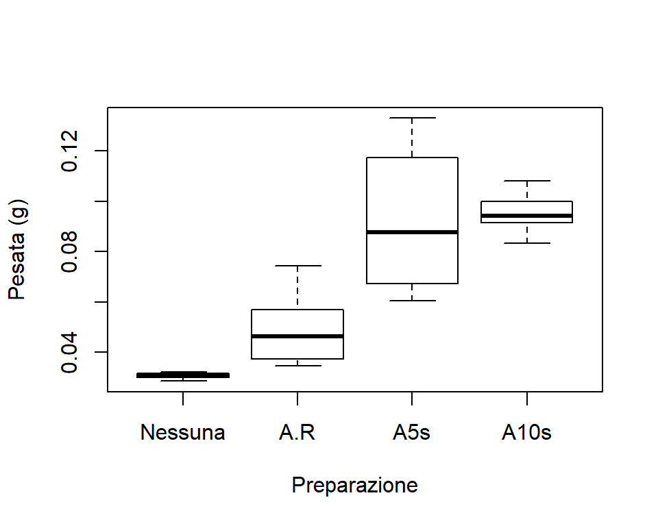

Boxplot

Consideriamo le seguenti somme di quadrati, che chiameremo *variazione tra gruppi*
$$\begin{equation*}
SS_{tra}=\sum_{j=1}^{n}\sum_{i=1}^{m_j}(\bar{y_j}-\bar{y})^2=\sum_{j=1}^{n}m_j(\bar{y_j}-\bar{y})^2
\end{equation*}$$
e *variazione nei gruppi* (variazione del residuo nel modello ())
$$\begin{equation*}
SS_{in}=\sum_{j=1}^{n}\sum_{i=1}^{m_j}(y_{ij}-\bar{y_j})^2.
\end{equation*}$$
Si può dimostrare che
$$\begin{equation*}
SS_{tot}=\sum_{j=1}^{n}\sum_{i=1}^{m_j}(y_{ij}-\bar{y})^2=SS_{in}+SS_{tra}.
\end{equation*}$$

Nel nostro esempio

```r
SS.tot=sum((Collirio$Pesata-mean(Collirio$Pesata))^2); SS.tot
```

```
## [1] 0.03253368
```

```r
medie=aggregate(Collirio$Pesata~Collirio$Preparazione,FUN = "mean"); medie
```

| Collirio$Preparazione | Collirio$Pesata |
| --- | --- |
| Nessuna | 0.0307125 |
| A.R | 0.0486875 |
| A5s | 0.0922375 |
| A10s | 0.0952750 |

```r
SS.tra=8*sum((medie$`Collirio$Pesata`-mean(Collirio$Pesata))^2); SS.tra
```

```
## [1] 0.02470593
```

```r
SS.in=sum((Collirio$Pesata[Collirio$Preparazione=="Nessuna"]-medie[1,2])^2)+
      sum((Collirio$Pesata[Collirio$Preparazione=="A.R"]-medie[2,2])^2)+
      sum((Collirio$Pesata[Collirio$Preparazione=="A5s"]-medie[3,2])^2)+
      sum((Collirio$Pesata[Collirio$Preparazione=="A10s"]-medie[4,2])^2); SS.in
```

```
## [1] 0.007827751
```

```r
SS.tra+SS.in
```

```
## [1] 0.03253368
```

Normalizziamo le somme di quadrati ottenendo le seguenti medie dei quadrati:
$$\begin{eqnarray*}
MS_{in} &=& \frac {SS_{in}}{m-n}\\
MS_{tra} &=& \frac {SS_{tra}}{n-1},
\end{eqnarray*}$$

dove $m=m_1+\dots+m_n$.

$MS_{in}$ è nota come la *varianza combinata* ed è uno stimatore della varianza comune $\sigma^2$. Si noti che (cf. ()):
$$\begin{equation*}
MS_{in}=s^2_c=\frac{(m_1-1)s_1^2+\cdots+(m_n-1)s_n^2}{m-n},
\end{equation*}$$

In assenza di un vero effetto di gruppo, anche $MS_{tra}$ è uno stimatore di $\sigma^2$, mentre se c’è un effettivo effetto di gruppo tende ad essere più larga.

```r
MS.tra=SS.tra/3; MS.tra
```

```
## [1] 0.008235311
```

```r
MS.in=SS.in/28; MS.in
```

```
## [1] 0.0002795625
```

```r
f.0=MS.tra/MS.in; f.0
```

```
## [1] 29.45785
```

Rigettiamo l’ipotesi nulla per valori di $\frac{MS_{tra}}{MS_{in}}$ maggiori del $(1-\alpha)$-esimo quantile ($\alpha$ livello di significatività) della distribuzione $F$. Si noti che il test è a una coda ($\frac{MS_{tra}}{MS_{in}} \geq 1$). Vedi Figura .

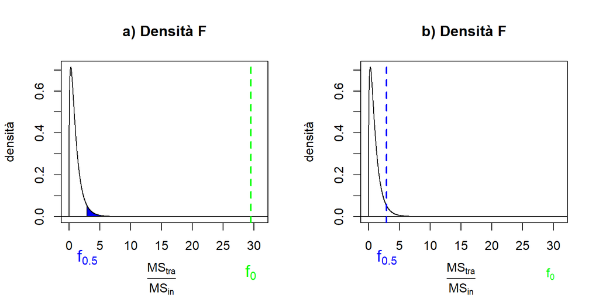

Test ipotesi $H_0: \frac{MS_{tra}}{MS_{in}}=1$

Nello studio di ogni singolo livello si procede come nel paragrafo con $s_c$ al posto di $s_j$ ($s_c$ è una stima migliore di $\sigma^2$), i.e.
$$\begin{equation*}
\frac{\bar y_j - \mu_j}{s_c \sqrt{1/m_j}} \sim t(m-n), \qquad \mu_i=\mu+\alpha_j,
\end{equation*}$$

la *varianza combinata* $s_c$ ha $(m_1-1)+\cdots+(m_n-1)=m-n$ gradi di libertà.

Tornando al nostro esempio calcoliamo *p-value*

```r
pf(q = f.0,df1 = 3,df2 = 28,lower.tail = FALSE)
```

```
## [1] 8.31549e-09
```

In **R** l’analisi della varianza si ottiene definendo il modello () mediante l’oggetto

```r
Collirio.aov=aov(Pesata~Preparazione,data=Collirio)
attributes(Collirio.aov)
```

```
## $names
##  [1] "coefficients"  "residuals"     "effects"       "rank"
##  [5] "fitted.values" "assign"        "qr"            "df.residual"
##  [9] "contrasts"     "xlevels"       "call"          "terms"
## [13] "model"
##
## $class
## [1] "aov" "lm"
```

e quindi mediante il comando

```r
summary(Collirio.aov)
```

```
##              Df   Sum Sq  Mean Sq F value   Pr(>F)
## Preparazione  3 0.024706 0.008235   29.46 8.32e-09 ***
## Residuals    28 0.007828 0.000280
## ---
## Signif. codes:  0 '***' 0.001 '**' 0.01 '*' 0.05 '.' 0.1 ' ' 1
```

in cui otteniamo i gradi di libertà, le somme quadratiche e le loro medie rispettivamente *tra gruppi* e *nei gruppi*, la statistica $\frac{MS_{tra}}{MS_{in}}$ e il valore del *p-value* del test d’ipotesi.

Il risultato del test sembra rifiutare l’ipotesi nulla (*p-value*<< 0.05), ma dobbiamo prima verificare che siano soddistfatte le ipotesi del modello ()

Per verificare la normalità dei residui usiamo il test di *Shapiro-Wilk*

```r
shapiro.test(Collirio.aov$residuals)
```

```
##
##  Shapiro-Wilk normality test
##
## data:  Collirio.aov$residuals
## W = 0.94947, p-value = 0.1392
```

che non evidenza la non normalità dei residui.

Per verificare l’omoschedasticità, ossia l’ipotesi di omogeneità delle varianze, vi sono vari test.  
Ne presentiamo alcuni (senza entrare nel dettaglio):

- il test di *Bartlett*: che ha il difetto di essere molto sensibile all’ipotesi di normalità dei dati (poco robusto)

```r
bartlett.test(Pesata~Preparazione,data=Collirio) # poco robusto
```

```
##
##  Bartlett test of homogeneity of variances
##
## data:  Pesata by Preparazione
## Bartlett's K-squared = 39.608, df = 3, p-value = 1.29e-08
```

- il test di *Fligner-Killeen*: più robusto per scostamenti dalla normalità

```r
fligner.test(Pesata~Preparazione,data=Collirio) # molto robusto
```

```
##
##  Fligner-Killeen test of homogeneity of variances
##
## data:  Pesata by Preparazione
## Fligner-Killeen:med chi-squared = 21.83, df = 3, p-value =
## 7.078e-05
```

- il test di *Levene*: da usare se diverse numerosità campionarie (non bilanciato)

```r
car::leveneTest(Pesata~Preparazione, data=Collirio)
```

|  | Df | F value | Pr(>F) |
| --- | --- | --- | --- |
| group | 3 | 20.95774 | 2.542849e-07 |
|  | 28 | NA | NA |

- il test di *Breusch-Pagan*: adatto a grandi campioni

```r
lmtest::bptest(Collirio.aov)
```

```
##
##  studentized Breusch-Pagan test
##
## data:  Collirio.aov
## BP = 20.285, df = 3, p-value = 0.0001481
```

- il test di *Cochran*: test della varianza massima (minima)

```r
outliers::cochran.test(Pesata~Preparazione, data=Collirio)
```

```
##
##  Cochran test for outlying variance
##
## data:  Pesata ~ Preparazione
## C = 0.771, df = 8, k = 4, p-value = 6.657e-05
## alternative hypothesis: Group A5s has outlying variance
## sample estimates:
##      Nessuna          A.R          A5s         A10s
## 1.609821e-06 1.995298e-04 8.621684e-04 5.494214e-05
```

Tutti questi test evidenziano che non è verificata l’ipotesi di omoschedasticità (*p-value*<<0.05).  
Il test Anova non è quindi applicabile.  
In questo caso si rivedono i dati, oppure si impiega un test non parametrico (Kruskal-Wallis).

**Esercizio -** Eseguire l’analisi della varianza per il dataset rivisto

```r
data(Collirio_1waov,package="Master")
Collirio_1waov
```

|  | Preparazione | Pesata |
| --- | --- | --- |
| 1 | Nessuna | 0.0185 |
| 2 | Nessuna | 0.0304 |
| 3 | Nessuna | 0.0295 |
| 4 | Nessuna | 0.0318 |
| 5 | Nessuna | 0.0303 |
| 6 | Nessuna | 0.0315 |
| 7 | Nessuna | 0.0322 |
| 8 | Nessuna | 0.0315 |
| 9 | A.R | 0.0377 |
| 10 | A.R | 0.0346 |

[output cut: 22 more lines]

Diamo innanzitutto un’occhiata grafica, vedi Figura , e numerica ai dati

```r
RcmdrMisc::numSummary(Collirio_1waov$Pesata,statistics = c("mean","sd"),
           groups = Collirio_1waov$Preparazione)
```

```
##              mean          sd data:n
## Nessuna 0.0294625 0.004520094      8
## A.R     0.0436875 0.006842188      8
## A5s     0.0723750 0.008013515      8
## A10s    0.0952750 0.007412297      8
```

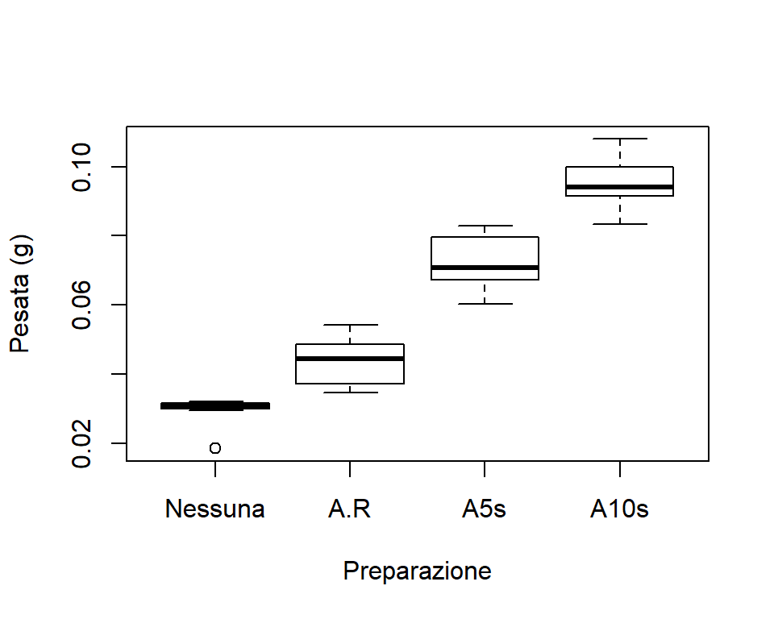

Boxplot

Definiamo innanzitutto il modello

```r
Collirio.aov.1=aov(Pesata~Preparazione,data=Collirio_1waov)
```

Controlliamo come prima cosa che siano verificate le ipotesi di normalità e di omoschedasticità dei residui:

- normalità

```r
shapiro.test(Collirio.aov.1$residuals)
```

```
##
##  Shapiro-Wilk normality test
##
## data:  Collirio.aov.1$residuals
## W = 0.97226, p-value = 0.5639
```

- omoschedasticità

```r
bartlett.test(Pesata~Preparazione,data=Collirio_1waov) # poco robusto
```

```
##
##  Bartlett test of homogeneity of variances
##
## data:  Pesata by Preparazione
## Bartlett's K-squared = 2.2113, df = 3, p-value = 0.5297
```

```r
fligner.test(Pesata~Preparazione,data=Collirio_1waov) # molto robusto
```

```
##
##  Fligner-Killeen test of homogeneity of variances
##
## data:  Pesata by Preparazione
## Fligner-Killeen:med chi-squared = 3.9844, df = 3, p-value = 0.2632
```

```r
car::leveneTest(Pesata~Preparazione, data=Collirio_1waov)
```

|  | Df | F value | Pr(>F) |
| --- | --- | --- | --- |
| group | 3 | 1.579396 | 0.2164789 |
|  | 28 | NA | NA |

```r
lmtest::bptest(Collirio.aov.1)
```

```
##
##  studentized Breusch-Pagan test
##
## data:  Collirio.aov.1
## BP = 2.6533, df = 3, p-value = 0.4482
```

```r
outliers::cochran.test(Pesata~Preparazione, data=Collirio_1waov)
```

```
##
##  Cochran test for outlying variance
##
## data:  Pesata ~ Preparazione
## C = 0.3445, df = 8, k = 4, p-value = 0.7879
## alternative hypothesis: Group A5s has outlying variance
## sample estimates:
##      Nessuna          A.R          A5s         A10s
## 2.043125e-05 4.681554e-05 6.421643e-05 5.494214e-05
```

Da tutti i test non abbiamo evidenza per poter rifiutare l’ipotesi di normalità e omoschedasticità. Possiamo quindi applicare il test ANOVA

```r
summary(Collirio.aov.1)
```

```
##              Df   Sum Sq  Mean Sq F value Pr(>F)
## Preparazione  3 0.020768 0.006923   148.5 <2e-16 ***
## Residuals    28 0.001305 0.000047
## ---
## Signif. codes:  0 '***' 0.001 '**' 0.01 '*' 0.05 '.' 0.1 ' ' 1
```

da cui si ha evidenza per rifiutare l’ipotesi nulla delle medie uguali (*p-value* <<0.05).

### ANOVA a 2 vie (con ripetizioni)

Consideriamo il dataset *Collirio_2waov*

```r
data(Collirio_2waov,package = "Master")
Collirio_2waov
```

|  | Preparazione | lotto | Pesata |
| --- | --- | --- | --- |
| 1 | Nessuna | 2150 | 0.0185 |
| 2 | Nessuna | 2150 | 0.0304 |
| 3 | Nessuna | 2150 | 0.0295 |
| 4 | Nessuna | 2150 | 0.0318 |
| 5 | Nessuna | 2151 | 0.0303 |
| 6 | Nessuna | 2151 | 0.0315 |
| 7 | Nessuna | 2151 | 0.0322 |
| 8 | Nessuna | 2151 | 0.0315 |
| 9 | A.R | 2150 | 0.0377 |
| 10 | A.R | 2150 | 0.0346 |

[output cut: 22 more lines]

Il dataset consiste nelle 32 misure sperimentali della *Pesata* di un collirio già trattate nell’esercizio del paragrafo precedente, in cui distinguiamo due fattori *Preparazione* [del campione] e *lotto*, numero di lotto di produzione del collirio.  
Il primo fattore ha 4 livelli (Nessuna, A.R, A5s e A10s), il secondo 2 (2150, 2151).

```r
str(Collirio_2waov)
```

```
## 'data.frame':    32 obs. of  3 variables:
##  $ Preparazione: Factor w/ 4 levels "Nessuna","A.R",..: 1 1 1 1 1 1 1 1 2 2 ...
##  $ lotto       : Factor w/ 2 levels "2150","2151": 1 1 1 1 2 2 2 2 1 1 ...
##  $ Pesata      : num  0.0185 0.0304 0.0295 0.0318 0.0303 0.0315 0.0322 0.0315 0.0377 0.0346 ...
```

Oltre alla modalità di preparazione si vuole verificare ora se la pesata di ogni goccia di collirio dipende anche dal fattore lotto di produzione+goccia

Possiamo rappresentare i dati in 4 colonne (una per ogni livello del fattore *Preparazione*) e 2 gruppi di righe (una per ogni livello del fattore *lotto*). Ci sono 4 ripetizioni in ognuna delle 8 celle *Preparazione x lotto*

```
##      Nessuna    A.R    A5s   A10s
## 2150  0.0185 0.0377 0.0677 0.0920
##       0.0304 0.0346 0.0604 0.0934
##       0.0295 0.0369 0.0673 0.0948
##       0.0318 0.0439 0.0674 0.1011
## 2151  0.0303 0.0485 0.0773 0.0833
##       0.0315 0.0488 0.0738 0.0909
##       0.0322 0.0448 0.0821 0.0987
##       0.0315 0.0543 0.0830 0.1080
```

Possiamo decomporre le osservazioni
$$\begin{equation*}
y_{ijk}=\bar{y}+(\bar{y_i}-\bar{y})+(\bar{y_j}-\bar{y})+(\bar{y}_{ij}-\bar{y_i}-\bar{y_j}+\bar{y})+(y_{ijk}-\bar{y}_{ij}),
\end{equation*}$$

dove $\bar{y}$ è la media delle 32 osservazioni, $\bar{y_i}$ è la media delle 16 osservazioni del $i$-esimo livello del fattore *lotto* (“2150” - righe 1:4 e “2151” - righe 5:8) e $\bar{y_j}$ è la media delle 8 osservazioni del $j$-esimo livello del fattore *Preparazione* (colonna $j$-esima) e $\bar{y}_{ij}$ è la media delle 4 osservazioni dell’intersezione del $i$- esimo livello del fattore *lotto* e del $j$- esimo livello del fattore *Preparazione* (“2150 x Nessuna” - righe 1:4 colonna 1,……., “2151 x A10s” - righe 5:8 colonna 4).

Supponiamo che i dati possano essere modellizzati ($\mu_i=\mu + \alpha_i, \mu_j = \mu + \beta_j, \mu_{ij}= \mu + (\mu_i - \mu) + (\mu_j - \mu) + (\alpha \beta)_{ij}$)
$$\begin{equation}\label{eq:ModAnova2Con}
y_{ijk}=\mu+\alpha_i+\beta_j+(\alpha\beta)_{ij}+\epsilon_{ijk}, \quad i=1,\dots,m, \ j=1,\dots,n, \ k=1,\dots,p
\end{equation}$$

con $\epsilon_{ijk}\sim N(0,\sigma^2)$ e a due a due non correlate. Nel nostro esempio numerico m=2, n=4, p=4.

Vogliamo testare se () è un effettivo modello che descrive i dati, ossia se statisticamente $\alpha_1=\alpha_2=\cdots=\alpha_m=0$ e/o $\beta_1=\beta_2=\cdots=\beta_n=0$ e/o $(\alpha\beta)_{1,1}=(\alpha\beta)_{2,2}=\cdots=(\alpha\beta)_{m,n}$ o esiste almeno un $i$ tale che $\alpha_i\neq0$ e/o esiste almeno un $j$ tale che $\beta_j\neq0$ e/o esiste almeno un $(i,j)$ tale che $(\alpha\beta)_{i,j}\neq0$ .

Diamo un’occhiata ai nostri dati, vedi Figura

```r
RcmdrMisc::numSummary(Collirio_2waov$Pesata,statistics = c("mean","sd"),
                      groups = Collirio_2waov$Preparazione:Collirio_2waov$lotto)
```

```
##                  mean           sd data:n
## Nessuna:2150 0.027550 0.0061070997      4
## Nessuna:2151 0.031375 0.0007889867      4
## A.R:2150     0.038275 0.0039735584      4
## A.R:2151     0.049100 0.0039149287      4
## A5s:2150     0.065700 0.0035374190      4
## A5s:2151     0.079050 0.0043023250      4
## A10s:2150    0.095325 0.0040161134      4
## A10s:2151    0.095225 0.0105859577      4
```

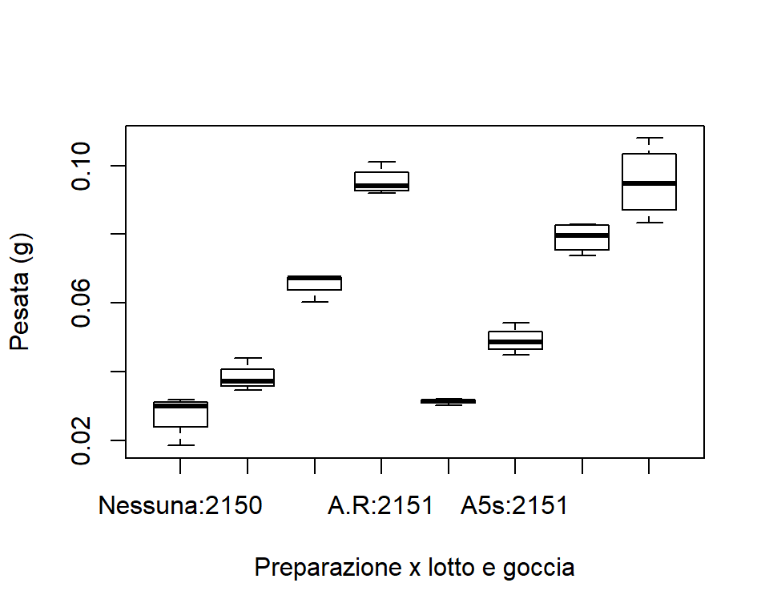

Boxplot

Consideriamo le seguenti somme di quadrati, che chiameremo
*variazione 2° Fattore*
$$\begin{equation*}
SS_{F2}=\sum_{i=1}^{m}\sum_{i=1}^{n}\sum_{k=1}^{p}(\bar{y_i}-\bar{y})^2=np\sum_{i=1}^{m}(\bar{y_i}-\bar{y})^2,
\end{equation*}$$
*variazione 1° Fattore*
$$\begin{equation*}
SS_{F1}=\sum_{i=1}^{m}\sum_{j=1}^{n}\sum_{k=1}^{p}(\bar{y_j}-\bar{y})^2=mp\sum_{j=1}^{n}(\bar{y_j}-\bar{y})^2,
\end{equation*}$$
*variazione interazione*
$$\begin{equation*}
SS_{inter}=\sum_{i=1}^{m}\sum_{j=1}^{n}\sum_{k=1}^{p}(y_{ij}-\bar{y_i}-\bar{y_j}+\bar{y})^2=
p\sum_{i=1}^{m}\sum_{j=1}^{n}(y_{ij}-\bar{y_i}-\bar{y_j}+\bar{y})^2.
\end{equation*}$$
e *variazione residua*
$$\begin{equation*}
SS_{res}=\sum_{i=1}^{m}\sum_{j=1}^{n}\sum_{k=1}^{p}(y_{ijk}-\bar{y}_{ij})^2.
\end{equation*}$$
Si può dimostrare che
$$\begin{equation*}
SS_{tot}=\sum_{i=1}^{m}\sum_{j=1}^{n}\sum_{k=1}^{p}(y_{ijk}-\bar{y})^2=SS_{F1}+SS_{F2}+SS_{inter}+SS_{res}.
\end{equation*}$$
Normalizziamo le somme di quadrati ottenendo le seguenti medie dei quadrati:
$$\begin{eqnarray*}
MS_{F1} &=& \frac {SS_{F1}}{m-1}\\
MS_{F2} &=& \frac {SS_{F2}}{n-1}\\
MS_{inter} &=& \frac {SS_{inter}}{(m-1)(n-1)}\\
MS_{res} &=& \frac {SS_{res}}{mn(p-1)}.
\end{eqnarray*}$$
Sotto l’ipotesi nulla che le medie delle celle righe/colonne siano uguali e interazione tra fattori nulla si ha che:
$$\begin{eqnarray*}
\frac {MS_{F1}}{MS_{res}} &\sim& F(m-1,mn(p-1))\\
\frac {MS_{F2}}{MS_{res}} &\sim& F(n-1,mn(p-1))\\
\frac {MS_{res}}{MS_{res}} &\sim& F((m-1)(n-1),mn(p-1))\\
\end{eqnarray*}$$
Possiamo eseguire i seguenti test d’ipotesi:
$$\begin{eqnarray*}
H_{0,1}: \alpha_i=0 \quad \forall i \quad & \rm{vs} & \quad H_{1,1}: \alpha_i\neq0 \quad \text{per almeno un} \quad i \\
H_{0,2}: \beta_j=0 \quad \forall j \quad & \rm{vs} & \quad H_{1,2}: \beta_j\neq0 \quad \text{per almeno un} \quad j
\end{eqnarray*}$$
e
$$\begin{eqnarray*}
H_{0,12}: (\alpha\beta)_{ij}=0 \quad \forall (i,j) \quad & \rm{vs} & \quad H_{1,12}: (\alpha\beta)_{ij}\neq 0 \quad \text{per almeno un} \quad (i,j).
\end{eqnarray*}$$

Ossia testare che:  
- $H_{0,1}$: le medie dei gruppi costituiti dalle modalità di *Preparazione* sono uguali tra loro  
- $H_{0,2}$: le medie dei gruppi costituiti per *lotto* sono uguali tra loro  
- $H_{0,12}$: non esiste interazione tra i due fattori *Preparazione* e numero di *lotto*. i.e. le medie degli 8 gruppi di dati individuati dalle interazioni a coppie tra i livelli dei fattori *Preparazione* e *lotto*.

In **R** l’analisi della varianza a 2 vie si ottiene definendo il modello () mediante l’oggetto

```r
Collirio.2aov=aov(Pesata ~ Preparazione*lotto,data=Collirio_2waov)
```

e quindi medinate il comando

```r
summary(Collirio.2aov)
```

```
##                    Df   Sum Sq  Mean Sq F value  Pr(>F)
## Preparazione        3 0.020768 0.006923 242.629 < 2e-16 ***
## lotto               1 0.000389 0.000389  13.641 0.00114 **
## Preparazione:lotto  3 0.000231 0.000077   2.697 0.06839 .
## Residuals          24 0.000685 0.000029
## ---
## Signif. codes:  0 '***' 0.001 '**' 0.01 '*' 0.05 '.' 0.1 ' ' 1
```

Per poter effettuare i test dobbiamo prima costruire il fattore Interazione

```r
Interazione=Collirio_2waov$Preparazione:Collirio_2waov$lotto
Collirio_2waov <- cbind(Collirio_2waov, Interaz=Interazione)

bartlett.test(Pesata~Interazione,data=Collirio_2waov) # poco robusto
```

```
##
##  Bartlett test of homogeneity of variances
##
## data:  Pesata by Interazione
## Bartlett's K-squared = 13.945, df = 7, p-value = 0.05217
```

```r
fligner.test(Pesata~Interazione,data=Collirio_2waov) # molto robusto
```

```
##
##  Fligner-Killeen test of homogeneity of variances
##
## data:  Pesata by Interazione
## Fligner-Killeen:med chi-squared = 12.038, df = 7, p-value =
## 0.09933
```

```r
car::leveneTest(Pesata~Preparazione*lotto, data=Collirio_2waov)
```

|  | Df | F value | Pr(>F) |
| --- | --- | --- | --- |
| group | 7 | 1.736843 | 0.1477302 |
|  | 24 | NA | NA |

```r
outliers::cochran.test(Pesata~Interaz,data=Collirio_2waov)
```

```
##
##  Cochran test for outlying variance
##
## data:  Pesata ~ Interaz
## C = 0.49096, df = 4, k = 8, p-value = 0.01845
## alternative hypothesis: Group A10s:2151 has outlying variance
## sample estimates:
## Nessuna:2150 Nessuna:2151     A.R:2150     A.R:2151     A5s:2150
## 3.729667e-05 6.225000e-07 1.578917e-05 1.532667e-05 1.251333e-05
##     A5s:2151    A10s:2150    A10s:2151
## 1.851000e-05 1.612917e-05 1.120625e-04
```

```r
lmtest::bptest(Collirio.2aov)
```

```
##
##  studentized Breusch-Pagan test
##
## data:  Collirio.2aov
## BP = 13.814, df = 7, p-value = 0.05459
```

**Esercizio -** Eseguire l’analisi della varianza (a 2 vie) del dataser rivisto

```r
data(Collirio_2waov.O,package = "Master")
Collirio_2waov.O
```

|  | Preparazione | lotto | Pesata |
| --- | --- | --- | --- |
| 1 | Nessuna | 2150 | 0.02754961 |
| 2 | Nessuna | 2150 | 0.02756465 |
| 3 | Nessuna | 2150 | 0.02755288 |
| 4 | Nessuna | 2150 | 0.02754558 |
| 5 | Nessuna | 2151 | 0.03139473 |
| 6 | Nessuna | 2151 | 0.03135752 |
| 7 | Nessuna | 2151 | 0.03136051 |
| 8 | Nessuna | 2151 | 0.03140203 |
| 9 | A.R | 2150 | 0.03827846 |
| 10 | A.R | 2150 | 0.03827622 |

[output cut: 22 more lines]

Diamo un’occhiata ai dati, vedi Figura

```r
RcmdrMisc::numSummary(Collirio_2waov.O$Pesata,statistics = c("mean","sd"),
                      groups=Collirio_2waov.O$Preparazione:Collirio_2waov.O$lotto)
```

```
##                    mean           sd data:n
## Nessuna:2150 0.02755318 8.209438e-06      4
## Nessuna:2151 0.03137870 2.295587e-05      4
## A.R:2150     0.03826218 1.804846e-05      4
## A.R:2151     0.04910856 2.047076e-05      4
## A5s:2150     0.06571051 1.239137e-05      4
## A5s:2151     0.07904339 1.757993e-05      4
## A10s:2150    0.09534116 1.725503e-05      4
## A10s:2151    0.09522308 3.264541e-05      4
```

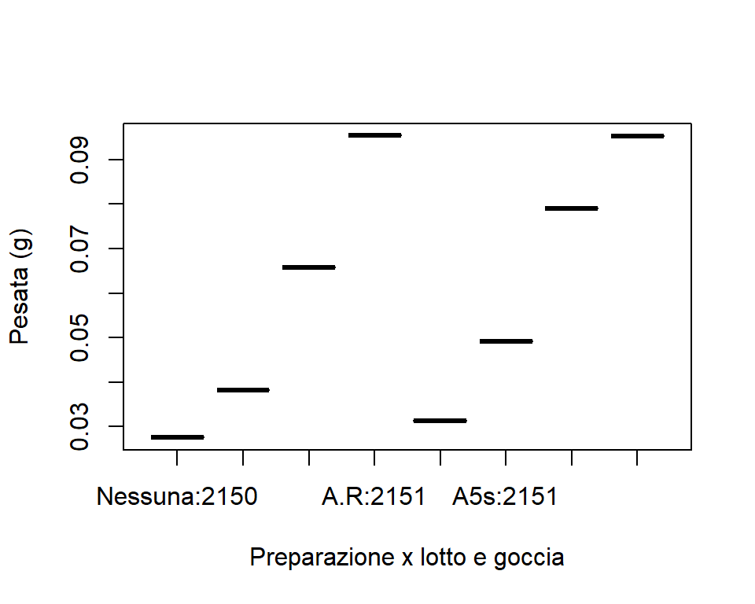

Boxplot

Costruiamo il modello ANOVA a 2 vie

```r
Collirio.2aov.O <- aov(Pesata ~ Preparazione*lotto , data=Collirio_2waov.O)
```

Verifichiamo, prima di procedere, l’omoschedasticità: Cosrtuiamo innanzitutto il Fattore Interazione

```r
Interazione=Collirio_2waov.O$Preparazione:Collirio_2waov.O$lotto
Collirio_2waov.O <- cbind(Collirio_2waov.O, Interaz=Interazione)

bartlett.test(Pesata~Interazione,data=Collirio_2waov.O) # poco robusto
```

```
##
##  Bartlett test of homogeneity of variances
##
## data:  Pesata by Interazione
## Bartlett's K-squared = 5.6196, df = 7, p-value = 0.5848
```

```r
fligner.test(Pesata~Interazione,data=Collirio_2waov.O) # molto robusto
```

```
##
##  Fligner-Killeen test of homogeneity of variances
##
## data:  Pesata by Interazione
## Fligner-Killeen:med chi-squared = 5.8939, df = 7, p-value = 0.5522
```

```r
outliers::cochran.test(Pesata~Interaz, data=Collirio_2waov.O)
```

```
##
##  Cochran test for outlying variance
##
## data:  Pesata ~ Interaz
## C = 0.3367, df = 4, k = 8, p-value = 0.2548
## alternative hypothesis: Group A10s:2151 has outlying variance
## sample estimates:
## Nessuna:2150 Nessuna:2151     A.R:2150     A.R:2151     A5s:2150
## 6.739487e-11 5.269717e-10 3.257470e-10 4.190521e-10 1.535459e-10
##     A5s:2151    A10s:2150    A10s:2151
## 3.090540e-10 2.977360e-10 1.065723e-09
```

```r
lmtest::bptest(Collirio.2aov.O)
```

```
##
##  studentized Breusch-Pagan test
##
## data:  Collirio.2aov.O
## BP = 9.6089, df = 7, p-value = 0.2118
```

```r
car::leveneTest(Pesata~Preparazione*lotto, data=Collirio_2waov.O)
```

|  | Df | F value | Pr(>F) |
| --- | --- | --- | --- |
| group | 7 | 0.8619835 | 0.5494929 |
|  | 24 | NA | NA |

Tutti i test non evidenzano problemi di omschedasticità (*p-value* >> 0.05), possiamo quindi applicare il test ANOVA

```r
summary(Collirio.2aov.O)
```

```
##                    Df   Sum Sq  Mean Sq  F value Pr(>F)
## Preparazione        3 0.020771 0.006924 17499161 <2e-16 ***
## lotto               1 0.000389 0.000389   982765 <2e-16 ***
## Preparazione:lotto  3 0.000231 0.000077   194853 <2e-16 ***
## Residuals          24 0.000000 0.000000
## ---
## Signif. codes:  0 '***' 0.001 '**' 0.01 '*' 0.05 '.' 0.1 ' ' 1
```

da cui si ha evidenza per poter rifiutare le ipotesi nulle $H_{0,1}, H_{0,2}$ e $H_{0,12}$. Ciò significa che gli effetti dovuti dai fattori *Preparazione*, *lotto* e dalla loro interazione sono significativi (non sono statisticamente trascurabili).  
Per una visualizazione grafica dell’interazione si veda Figura

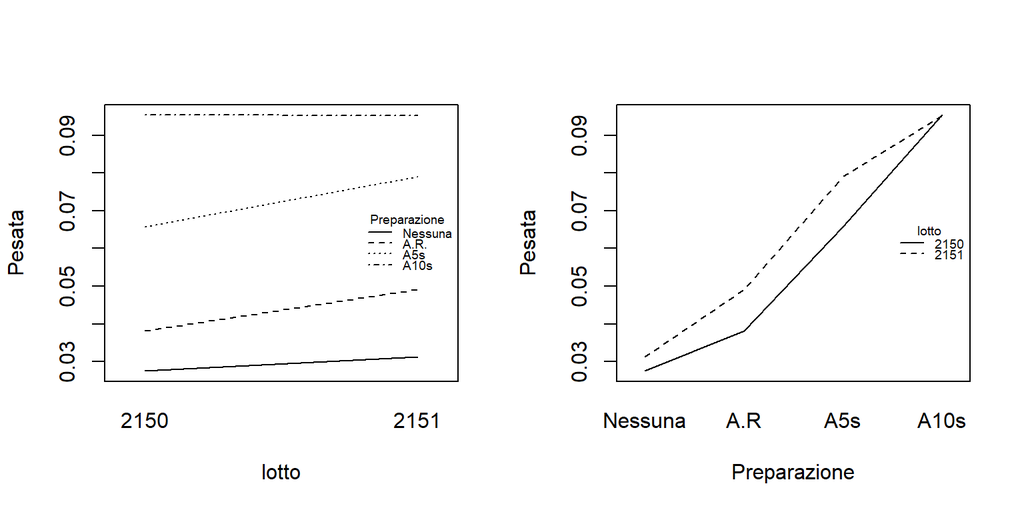

Grafico interazione

### ANOVA a 3 vie (senza ripetizioni)

Condideriamo il dataset

```r
data(Collirio_3waov,package = "Master")
Collirio_3waov
```

|  | Preparazione | lotto | goccia | Pesata |
| --- | --- | --- | --- | --- |
| 1 | Nessuna | 2150 | 1 | 0.0185 |
| 2 | Nessuna | 2150 | 2 | 0.0304 |
| 3 | Nessuna | 2150 | 3 | 0.0295 |
| 4 | Nessuna | 2150 | 4 | 0.0318 |
| 5 | Nessuna | 2151 | 1 | 0.0303 |
| 6 | Nessuna | 2151 | 2 | 0.0315 |
| 7 | Nessuna | 2151 | 3 | 0.0322 |
| 8 | Nessuna | 2151 | 4 | 0.0315 |
| 9 | A.R | 2150 | 1 | 0.0377 |
| 10 | A.R | 2150 | 2 | 0.0346 |

[output cut: 22 more lines]

Il dataset consiste nelle 32 misure sperimentali della Pesata di un collirio trattate all’inizio del paragrafo precedente, a cui è stato aggiunto un terzo fattore *goccia* a 4 livelli (1,2,3,4) che verifica se si realizza una dose media diversa di farmaco nelle prime 4 gocce prelevate dai flaconcini di collirio dei due lotti dopo la *Preparazione* del prodotto.

```r
str(Collirio_3waov)
```

```
## 'data.frame':    32 obs. of  4 variables:
##  $ Preparazione: Factor w/ 4 levels "Nessuna","A.R",..: 1 1 1 1 1 1 1 1 2 2 ...
##  $ lotto       : Factor w/ 2 levels "2150","2151": 1 1 1 1 2 2 2 2 1 1 ...
##  $ goccia      : Factor w/ 4 levels "1","2","3","4": 1 2 3 4 1 2 3 4 1 2 ...
##  $ Pesata      : num  0.0185 0.0304 0.0295 0.0318 0.0303 0.0315 0.0322 0.0315 0.0377 0.0346 ...
```

Consideriamo il modello ANOVA a 3 fattori con interazioni

```r
Collirio.3aov <- aov(Pesata ~ Preparazione + lotto+ goccia + # 3 termini lineari
                              Preparazione:lotto + Preparazione:goccia +
                              lotto:goccia + # 3 interazioni binarie
                              Preparazione:lotto:goccia, # 1 interazione ternaria
                     data=Collirio_3waov)
```

Il numero di prove (non replicate) è pari a 4x2x4 = 32, non ci sono quindi gradi di libertà e nessuna inferenza è possibile

```r
summary(Collirio.3aov)
```

```
##                           Df   Sum Sq  Mean Sq
## Preparazione               3 0.020768 0.006923
## lotto                      1 0.000389 0.000389
## goccia                     3 0.000323 0.000108
## Preparazione:lotto         3 0.000231 0.000077
## Preparazione:goccia        9 0.000224 0.000025
## lotto:goccia               3 0.000006 0.000002
## Preparazione:lotto:goccia  9 0.000132 0.000015
```

Per una visione grafica delle interazioni si vedano le Figure e

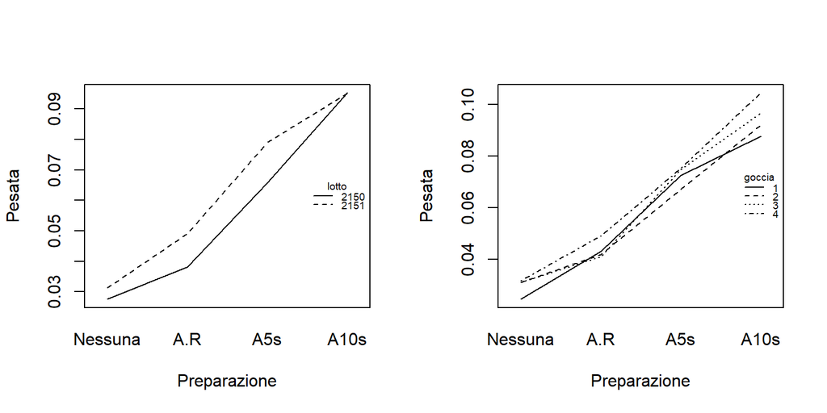

Plot interazioni binarie

[figure not shown]

Plot interazioni ternarie